# Machine Learning assignement: Qualitative Activity Recognition of Weight Lifting Exercises

The aim of this study is to design a model via Machine Mearning that enables us to determine if a lifting exercise was well performed or not. This by using the data from sensors worn by the sportsman on his/her arms, on the gloves, on the belt and on the dumbell. The data are from: http://groupware.les.inf.puc-rio.br/har

Two sets were downloaded:

- the training data, used to build the model and calculate the accuracy of the model: https://d396qusza40orc.cloudfront.net/predmachlearn/pml-training.csv
- the test data, used for the quizz: https://d396qusza40orc.cloudfront.net/predmachlearn/pml-testing.csv

# Getting the data

The two data sets were downloaded and read by the read.csv function in R. The different packages were also downloaded at the same time. The column *classe* was set as a factor to ease the building of the model.

```r
library(dplyr)
library(caret)
library(doParallel)

set.seed(2000)

dftest <- read.csv("pml-testing.csv", stringsAsFactors = FALSE, na.strings = c("#DIV/0!", "NA", ""), sep = ",", dec = ".")
df <- read.csv("pml-training.csv", stringsAsFactors = FALSE, na.strings = c("#DIV/0!", "NA", ""), sep = ",", dec = ".")
df$classe <- as.factor(df$classe)
```

# Cleaning the data

If we take a look at the test data set, we can observe that the columns about average, standard deviation, variance are completely filled with NA’s. Thus we cannot use them in the building of the model.

```r
#keep the one with no NA values in the test set
co <- names(dftest[,colSums(is.na(dftest)) == 0])

df <- select(df, one_of(c(co, "classe")))
dftest <- dftest[,co]
```

Moreover, the first seven columns are either characters, or time serie data. We will not use them. That is why, there are removed from the training and test data sets.

```r
#remove the first columns
df <- df[,-(1:7)]
dftest <- dftest[,-(1:7)]
```

We can also check that the predictors that we have left have a variance different of 0. But none of the predictors that are left have a null variance.

```r
nsv <- nearZeroVar(df, saveMetrics = T)
which(nsv[,4]== TRUE)
```

```
## integer(0)
```

So we have now data sets that have the following dimension:

```r
dim(df)
```

```
## [1] 19622    53
```

```r
dim(dftest)
```

```
## [1] 20 53
```

# Partionning the data

In order to assess the model’s accuracy, we need to have a training and a testing test. They are obtained by splitting the training data set.

```r
split <- createDataPartition( y= df$classe, p = 0.7, list = FALSE)
training <- df[split,]
test <- df[-split,]
```

They have the following dimension:

```r
dim(training)
```

```
## [1] 13737    53
```

```r
dim(test)
```

```
## [1] 5885   53
```

# Building of models

Several models are looked at and accuracy is the mean to determine which one is the best model. The aim is to have an accuracy of at least 0.99 to be able to pass the quizz. For all the models (except the first one), parallel processing is used in order to reduce the time of calculation. For these ones a 5-fold cross-validation was chosen.

## Decision Tree

Because we search to match a model link to cassification, decision tree can be a good model.

```r
model <- train(classe ~., method = "rpart", data = training)
prediction <- predict(model, newdata = test)
acctest <- confusionMatrix(prediction, test$classe)
```

The accuracy is really low (0.49). That is why, another model will be used.

```
## Confusion Matrix and Statistics
##
##           Reference
## Prediction    A    B    C    D    E
##          A 1510  461  465  460  164
##          B   34  403   25  152  157
##          C  129  275  536  352  270
##          D    0    0    0    0    0
##          E    1    0    0    0  491
##
## Overall Statistics
##
##                Accuracy : 0.4996
##                  95% CI : (0.4867, 0.5124)
##     No Information Rate : 0.2845
##     P-Value [Acc > NIR] : < 2.2e-16
##
##                   Kappa : 0.3459
##  Mcnemar's Test P-Value : NA
##
## Statistics by Class:
##
##                      Class: A Class: B Class: C Class: D Class: E
## Sensitivity            0.9020  0.35382  0.52242   0.0000  0.45379
## Specificity            0.6319  0.92246  0.78885   1.0000  0.99979
## Pos Pred Value         0.4935  0.52270  0.34315      NaN  0.99797
## Neg Pred Value         0.9419  0.85608  0.88665   0.8362  0.89041
## Prevalence             0.2845  0.19354  0.17434   0.1638  0.18386
## Detection Rate         0.2566  0.06848  0.09108   0.0000  0.08343
## Detection Prevalence   0.5200  0.13101  0.26542   0.0000  0.08360
## Balanced Accuracy      0.7670  0.63814  0.65563   0.5000  0.72679
```

## Boosting

In that case, boosting with trees will be used, via the method “gbm” in the caret package.

```r
cluster <- makeCluster(detectCores() - 1) # convention to leave 1 core for OS
registerDoParallel(cluster)

fitControl <- trainControl(method = "cv",
                           number = 5,
                           allowParallel = TRUE)

model2 <- train(classe ~. , method = "gbm", data = training, verbose = F, trControl = fitControl)

stopCluster(cluster)
registerDoSEQ()
prediction2 <- predict(model2, newdata = test)
acctest2 <- confusionMatrix(prediction2, test$classe)
```

The accuracy that is obtained is lot higher than with decision tree (0.96). However, it is still not good enough.

```
## Confusion Matrix and Statistics
##
##           Reference
## Prediction    A    B    C    D    E
##          A 1651   39    0    1    2
##          B   13 1063   33    8   20
##          C    8   34  980   29    8
##          D    2    3   11  918   14
##          E    0    0    2    8 1038
##
## Overall Statistics
##
##                Accuracy : 0.9601
##                  95% CI : (0.9547, 0.9649)
##     No Information Rate : 0.2845
##     P-Value [Acc > NIR] : < 2.2e-16
##
##                   Kappa : 0.9495
##  Mcnemar's Test P-Value : 5.705e-09
##
## Statistics by Class:
##
##                      Class: A Class: B Class: C Class: D Class: E
## Sensitivity            0.9863   0.9333   0.9552   0.9523   0.9593
## Specificity            0.9900   0.9844   0.9837   0.9939   0.9979
## Pos Pred Value         0.9752   0.9349   0.9254   0.9684   0.9905
## Neg Pred Value         0.9945   0.9840   0.9905   0.9907   0.9909
## Prevalence             0.2845   0.1935   0.1743   0.1638   0.1839
## Detection Rate         0.2805   0.1806   0.1665   0.1560   0.1764
## Detection Prevalence   0.2877   0.1932   0.1799   0.1611   0.1781
## Balanced Accuracy      0.9881   0.9588   0.9695   0.9731   0.9786
```

## Random Forest

In order to get a better model, Random Forest alorithm will be used.

```r
cluster <- makeCluster(detectCores() - 1) # convention to leave 1 core for OS
registerDoParallel(cluster)

fitControl <- trainControl(method = "cv",
                           number = 5,
                           allowParallel = TRUE)

model3 <- train(classe ~. , method = "rf", data = training, trControl = fitControl, verbose = F)

stopCluster(cluster)
registerDoSEQ()

prediction3 <- predict(model3, newdata = test)
acctest3 <- confusionMatrix(prediction3, test$classe)
```

```r
model3
```

```
## Random Forest
##
## 13737 samples
##    52 predictor
##     5 classes: 'A', 'B', 'C', 'D', 'E'
##
## No pre-processing
## Resampling: Cross-Validated (5 fold)
## Summary of sample sizes: 10989, 10991, 10989, 10991, 10988
## Resampling results across tuning parameters:
##
##   mtry  Accuracy   Kappa
##    2    0.9910466  0.9886725
##   27    0.9903194  0.9877527
##   52    0.9850784  0.9811219
##
## Accuracy was used to select the optimal model using the largest value.
## The final value used for the model was mtry = 2.
```

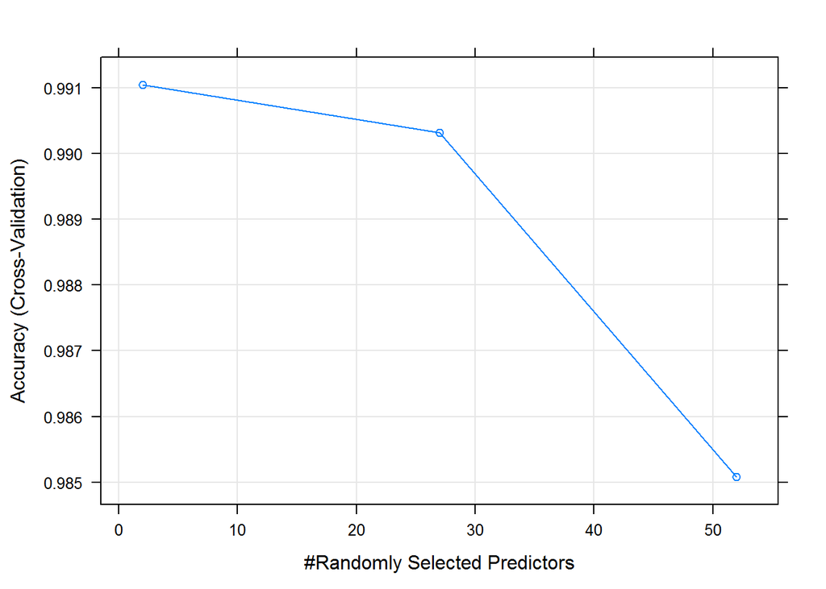

```r
plot(model3)
```

The accuracy is very good (0.99). Meaning that we can use this model for further tests.

```
## Confusion Matrix and Statistics
##
##           Reference
## Prediction    A    B    C    D    E
##          A 1671    3    0    0    0
##          B    3 1131    4    0    0
##          C    0    5 1021   21    0
##          D    0    0    1  942    4
##          E    0    0    0    1 1078
##
## Overall Statistics
##
##                Accuracy : 0.9929
##                  95% CI : (0.9904, 0.9949)
##     No Information Rate : 0.2845
##     P-Value [Acc > NIR] : < 2.2e-16
##
##                   Kappa : 0.991
##  Mcnemar's Test P-Value : NA
##
## Statistics by Class:
##
##                      Class: A Class: B Class: C Class: D Class: E
## Sensitivity            0.9982   0.9930   0.9951   0.9772   0.9963
## Specificity            0.9993   0.9985   0.9946   0.9990   0.9998
## Pos Pred Value         0.9982   0.9938   0.9752   0.9947   0.9991
## Neg Pred Value         0.9993   0.9983   0.9990   0.9955   0.9992
## Prevalence             0.2845   0.1935   0.1743   0.1638   0.1839
## Detection Rate         0.2839   0.1922   0.1735   0.1601   0.1832
## Detection Prevalence   0.2845   0.1934   0.1779   0.1609   0.1833
## Balanced Accuracy      0.9987   0.9958   0.9949   0.9881   0.9980
```

We can then use this model, to predict the 20 test cases:

```r
predictionfinal <- predict(model3, newdata = dftest)
predictionfinal
```

```
##  [1] B A B A A E D B A A B C B A E E A B B B
## Levels: A B C D E
```

# Conclusion

We were able to obtain an accuracy of 0.99 by building a model using Random Forests, with a 5-fold cross-validation.